# Linear mixed models in R: nitty-gritty

Ben Bolker

12 November 2018

Licensed under the [Creative Commons attribution-noncommercial license](http://creativecommons.org/licenses/by-nc/3.0/). Please share & remix noncommercially, mentioning its origin.

# Model specification

## Distribution/family

- going to assume Gaussian (Normal) here
- may need to transform
- we care about the **conditional** distribution, not the marginal
- Box-Cox not implemented: could try `MASS::boxcox()` on residuals
- brute-force: if it makes sense or *if* residuals look bad, try log/sqrt?
- bias $\gg$ heteroscedasticity/outliers $\gg$ Normality

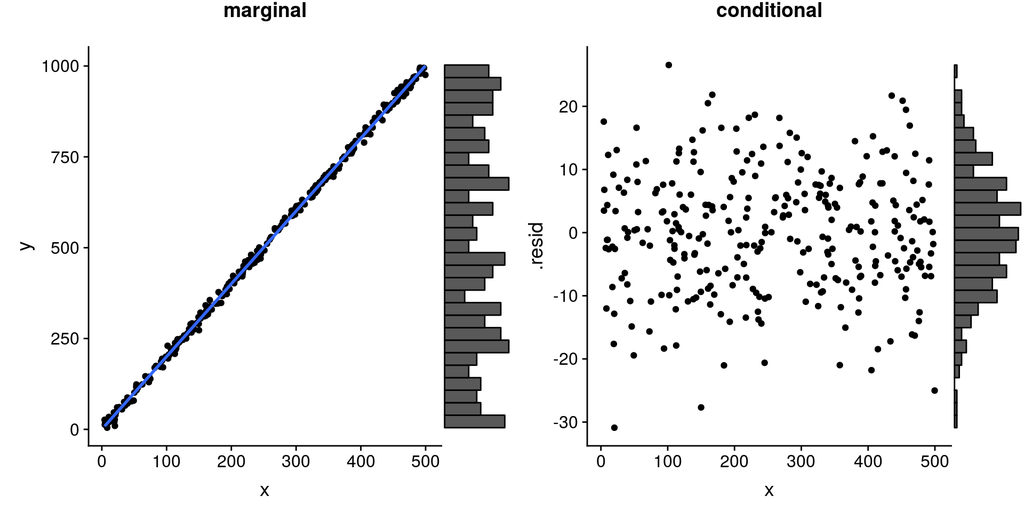

## Look at your data!

- use `table()` to confirm how many observations per level of factor
  - which factors covary?
  - balanced?
- plot the data

## Random effects: reminder (Bolker 2015)

- don’t want to test differences across specific groups
- lots of groups (>5), few observations per group, unbalanced
- exchangeable groups

## Formulas

- random effects specified with `|` as `(a|g1) + (b|g2) + ...`
- right-hand side is the *grouping variable* (always categorical, usually a factor)
- left-hand side is the *varying term* (most often 1)s
- terms separated by `+` are independent

| equation | formula |
| --- | --- |
| $β_0 + β_{1}X_{i} + e_{si}$ | n/a (Not a mixed-effects model) |
| $(β_0 + b_{S,0s}) + β_{1}X_i + e_{si}$ | `∼ X + (1∣Subject)` |
| $(β_0 + b_{S,0s}) + (β_{1} + b_{S,1s}) X_i + e_{si}$ | `~ X + (1 + X∣Subject)` |
| $(β_0 + b_{S,0s} + b_{I,0i}) + (β_{1} + b_{S,1s}) X_i + e_{si}$ | `∼ X + (1 + X∣Subject) + (1∣Item)` |
| As above, but $S_{0s}$, $S_{1s}$ independent | `∼ X + (1∣Subject) + (0 + X∣ Subject) + (1∣Item)` |
| $(β_0 + b_{S,0s} + b_{I,0i}) + β_{1}X_i + e_{si}$ | `∼ X + (1∣Subject) + (1∣Item)` |
| $(β_0 + b_{I,0i}) + (β_{1} + b_{S,1s})X_i + e_{si}$ | `∼ X + (0 + X∣Subject) + (1∣Item)` |

Modified from: http://stats.stackexchange.com/questions/13166/rs-lmer-cheat-sheet?lq=1 (Livius)

## Formulas, interactions, nesting etc.

`a*b` = main effects plus interaction, `a:b` = interaction only, `a/b` = `a` + `a:b`

- Nested: `(1|f/g)` equivalent to `(1|f) + (1|f:g)`. e.g. subplots vary within plots (but “subplot 1 of every plot” isn’t meaningful)
- Crossed: `(1|f) + (1|g)`. e.g. years vary, and plots vary independently
- Crossed+: `(1|f) + (1|g) + (1|f:g)`. e.g. years vary, and plots vary independently, and plots also vary *within* years (for LMMs, assumes >1 observation per plot/year combination). (`(1|f*g)` should be allowed but …)

Don’t need explicit nesting if your sub-groups are uniquely labeled (i.e. `A1`, `A2`, …, `B1`, `B2`, …)

## What is the maximal model?

- Which effects vary *within* which groups?
- If effects don’t vary within groups, then we *can’t* estimate among-group variation in the effect
  - convenient
  - maybe less powerful (among-group variation is lumped into residual variation)
- e.g. female rats exposed to different doses of radiation, multiple pups per mother, multiple measurements per pup (labeled by time). Maximal model … ?

Maximal model **often won’t work**

## Random-slopes models: what does `(x|g)` really do?

- equivalent to `(1+x|g)`
- both intercept (baseline) and slope vary across groups
- estimates **bivariate** zero-centered distribution:

$$(\textrm{intercept}, \textrm{slope}) =
\textrm{MVN}\left(\boldsymbol 0,
\left[
\begin{array}{cc}
\sigma^2_{\textrm{int}} &
\sigma_{\textrm{int},\textrm{slope}} \\
\sigma_{\textrm{int},\textrm{slope}} &
\sigma^2_{\textrm{slope}}
\end{array}
\right]
\right)$$

- maximal model can get very complicated (e.g. `(1+x+y+z+...|g)`: $n$ effects require $n(n+1)/2$ variances + covariances

## Other FAQs

- Can you have continuous variables as REs?  
  A: yes, as *varying terms*, but not as *grouping variables*
- Can a variable be in the model as both FE and RE?  
  A: only in the special case where $x$ is numeric but discrete (e.g. year) and >1 observation per $x$ value;  
  FE describes overall trend, RE describes variation around the trend

## What is a practical model?

- Fits aren’t **singular**
- singular = zero variances, +/- 1 correlations
- More subtle for larger models:  
  `all(abs(getME(x,"theta"))>1e-4)`

## Why are fits singular?

Essentially, because the *observed* among-group variation is less than the *expected* among-group variation (= $\sigma^2_{\mbox{among}} + \sigma^2_{\mbox{within}}/n$). More generally, because *some* dimension of the variance-covariance matrix has zero extent …

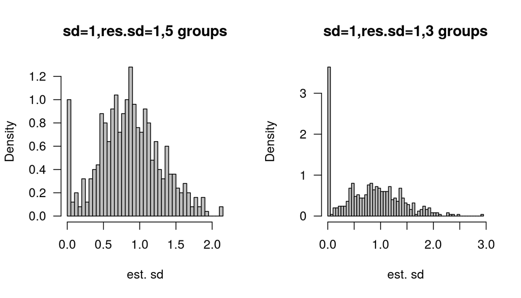

## Fit model

```r
m1 <- lmer(Reaction ~ Days + (Days|Subject), sleepstudy)
```

## Diagnostics: residual scale

Similar to generalized linear models: fitted vs. residual, scale-location, Q-Q

```r
aa <- augment(m1)
## fitted vs resid
plot(m1,type=c("p","smooth"))
## scale-location
plot(m1,sqrt(abs(resid(.)))~fitted(.),type=c("p","smooth"))
## q-q
lattice::qqmath(m1,id=0.05)
```

Or with `augment` and ggplot …

```r
aa <- augment(m1)
## fitted vs resid
ggplot(aa,aes(.fitted,.resid))+geom_point()+geom_smooth()
## scale-location
ggplot(aa,aes(.fitted,sqrt(abs(.resid))))+geom_point()+geom_smooth()
## q-q
ggplot(aa)+stat_qq(aes(sample=.resid))
```

# The broom/broom.mixed packages

- `tidy`: get coefficient values
  - `effects="fixed"`
  - `effects="ran_vars"`
  - `effects="ran_vals"`
  - `effects="ran_coefs"`
- `glance`: get model summaries
- `augment`: get fitted, residuals, possibly predictions

# Inference

## Likelihood

- probability of data given model
- for mixed models, includes the integral over the random effects

## Wald approximation

most important:

- small sample sizes
- values near boundaries
  - changing scales may help

more important for variance parameters than fixed-effect parameters

## Finite-size corrections

e.g. Normal vs. $t$

## Inference: fixed effects, Wald

- parameter estimates: `summary()`
- termwise tests: `car::Anova`, `afex::anova`
- contrasts/effects/post-hoc tests: `emmeans`, `effects` packages

```r
car::Anova(m1)
```

## Degrees of freedom

- level-counting: `R/calcDenDF.R`
- `lmerTest`/`afex`; Satterthwaite, Kenward-Roger

```r
library(lmerTest)
summary(as_lmerModLmerTest(m1))
```

```
## Linear mixed model fit by REML. t-tests use Satterthwaite's method [
## lmerModLmerTest]
## Formula: Reaction ~ Days + (Days | Subject)
##    Data: sleepstudy
##
## REML criterion at convergence: 1743.6
##
## Scaled residuals:
##     Min      1Q  Median      3Q     Max
## -3.9536 -0.4634  0.0231  0.4634  5.1793
##
## Random effects:
##  Groups   Name        Variance Std.Dev. Corr
##  Subject  (Intercept) 612.09   24.740
##           Days         35.07    5.922   0.07
##  Residual             654.94   25.592
## Number of obs: 180, groups:  Subject, 18
##
## Fixed effects:
##             Estimate Std. Error      df t value Pr(>|t|)
## (Intercept)  251.405      6.825  17.000  36.838  < 2e-16 ***
## Days          10.467      1.546  17.000   6.771 3.26e-06 ***
## ---
## Signif. codes:  0 '***' 0.001 '**' 0.01 '*' 0.05 '.' 0.1 ' ' 1
##
## Correlation of Fixed Effects:
##      (Intr)
## Days -0.138
```

```r
summary(as_lmerModLmerTest(m1),ddf="Kenward-Roger")
```

```
## Linear mixed model fit by REML. t-tests use Kenward-Roger's method [
## lmerModLmerTest]
## Formula: Reaction ~ Days + (Days | Subject)
##    Data: sleepstudy
##
## REML criterion at convergence: 1743.6
##
## Scaled residuals:
##     Min      1Q  Median      3Q     Max
## -3.9536 -0.4634  0.0231  0.4634  5.1793
##
## Random effects:
##  Groups   Name        Variance Std.Dev. Corr
##  Subject  (Intercept) 612.09   24.740
##           Days         35.07    5.922   0.07
##  Residual             654.94   25.592
## Number of obs: 180, groups:  Subject, 18
##
## Fixed effects:
##             Estimate Std. Error      df t value Pr(>|t|)
## (Intercept)  251.405      6.825  17.000  36.838  < 2e-16 ***
## Days          10.467      1.546  17.000   6.771 3.26e-06 ***
## ---
## Signif. codes:  0 '***' 0.001 '**' 0.01 '*' 0.05 '.' 0.1 ' ' 1
##
## Correlation of Fixed Effects:
##      (Intr)
## Days -0.138
```

Q: Why not use `lmerTest` all the time?  
A: it can make it a little harder to diagnose fitting problems

## Inference: fixed effects, likelihood ratio test

- individual parameters: `profile()`, `confint()`
- fit pairwise models and use `anova()` to compare
- `drop1`, `afex::anova()`

```r
confint(m1)
```

```
## Computing profile confidence intervals ...
```

```
##                   2.5 %     97.5 %
## .sig01       14.3815048  37.715996
## .sig02       -0.4815007   0.684986
## .sig03        3.8011641   8.753383
## .sigma       22.8982669  28.857997
## (Intercept) 237.6806955 265.129515
## Days          7.3586533  13.575919
```

What took so long?

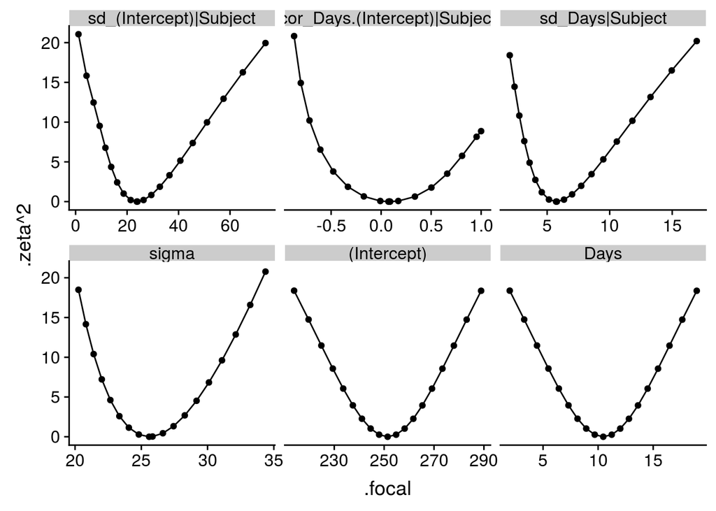

## Inference: parametric bootstrap

Very slow!

- `pbkrtest`
- `confint(.,method="boot")`

## Inference: random effects

- Wald is probably very bad
- profile, `anova()`
- parametric bootstrap
- boundary problems

## Inference: CIs on predictions etc.

```r
mm <- model.matrix(terms(fitted_model),newdat)
se_pred <- sqrt(diag(mm %*% tcrossprod(vcov(fitted_model),mm)))
```

## emmeans etc.

```r
data("Oats",package="nlme")
m_oats <- lmer(yield~nitro*Variety+(1|Block),data=Oats)
(e1 <- emmeans(m_oats,~nitro|Variety))
```

```
## Variety = Golden Rain:
##  nitro   emmean       SE   df lower.CL upper.CL
##    0.3 104.5000 7.124279 6.61 87.45087 121.5491
##
## Variety = Marvellous:
##  nitro   emmean       SE   df lower.CL upper.CL
##    0.3 109.7917 7.124279 6.61 92.74254 126.8408
##
## Variety = Victory:
##  nitro   emmean       SE   df lower.CL upper.CL
##    0.3  97.6250 7.124279 6.61 80.57587 114.6741
##
## Degrees-of-freedom method: kenward-roger
## Confidence level used: 0.95
```

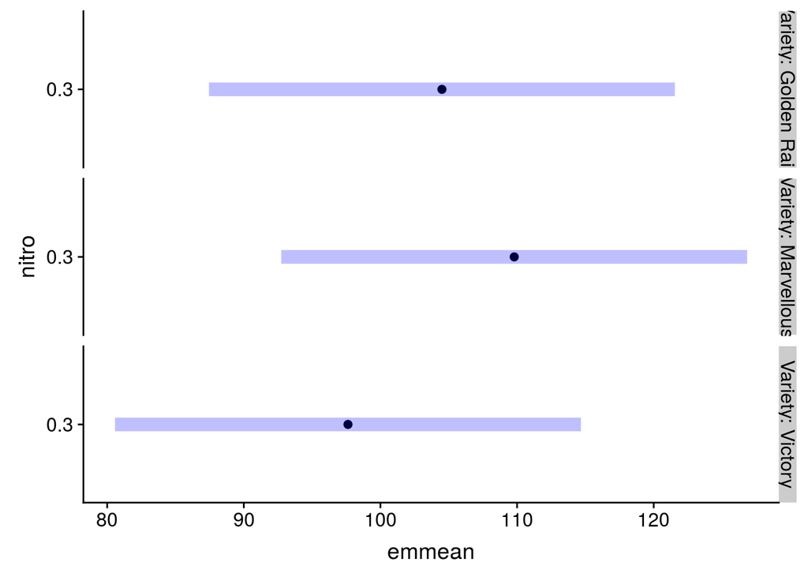

```r
plot(e1)
```

```r
e2 <- emmeans(m_oats,~Variety)
```

```
## NOTE: Results may be misleading due to involvement in interactions
```

```r
##
contrast(e2,"pairwise")
```

```
##  contrast                  estimate       SE df t.ratio p.value
##  Golden Rain - Marvellous -5.291667 4.469012 61  -1.184  0.4671
##  Golden Rain - Victory     6.875000 4.469012 61   1.538  0.2804
##  Marvellous - Victory     12.166667 4.469012 61   2.722  0.0226
##
## P value adjustment: tukey method for comparing a family of 3 estimates
```

also see the `effects` package.

```r
car::Anova(m_oats,test="F")
```

```
## Analysis of Deviance Table (Type II Wald F tests with Kenward-Roger df)
##
## Response: yield
##                     F Df Df.res    Pr(>F)
## nitro         81.5155  1     61 7.648e-13 ***
## Variety        3.7268  2     61   0.02972 *
## nitro:Variety  0.3512  2     61   0.70524
## ---
## Signif. codes:  0 '***' 0.001 '**' 0.01 '*' 0.05 '.' 0.1 ' ' 1
```

Bolker, Benjamin M. 2015. “Linear and Generalized Linear Mixed Models.” In *Ecological Statistics: Contemporary Theory and Application*, edited by Gordon A. Fox, Simoneta Negrete-Yankelevich, and Vinicio J. Sosa. Oxford University Press.